# Weather report

Oleksandr Myronov

10 05 2021

# TORNADOS are the most dangerous weather event with respect to population health and FLOODS caused the most economical damage in US during 2001-2011 years.

In this study we explored weather data records for period 01.01.2001-30.11.2011, which caused fatalities, injuries or economic damage (144826 records in subset). We defined tornado as weather event, which caused the most fatalities (1152, 20.9% of total) and injuries (14332, 44.3% of total) among all weather-related, across the whole USA. Tornado is generalized word for similar weather events, like whirlwind, landspout, waterspout and funnel cloud. Tornado statistics include [2011 Super Outbreak](https://en.wikipedia.org/wiki/2011_Super_Outbreak) period, which is not common annual activity for tornadoes.

With respect to economics, flood was defined as most harmful event, which caused the most property damage (145.5 Billions USD, 44.8% of total) and crops damage (4.4 Billions USD, 21.9% of total, but flood is just TOP-2 for crops, TOP-1 is drought) among all weather-related damage, across the whole USA. Flood is generalized word for high water and water streams.

TOP-12 dangerous weather events caused ~95% of injuries and fatalities, and similar TOP-12 caused 99.4% economic damage. More detailed statistics can be found in **Results** section.

In this study we explored that the most dangerous and harmful events significantly differs across the US regions, due to different natural conditions. Short summary about TOP-1 dangerous and TOP-1 harmful event for each region can be found in **Localization Summary** section.

## Data Processing

#### Loading Data

Original dataset was loaded from [https://d396qusza40orc.cloudfront.net](https://d396qusza40orc.cloudfront.net/repdata%2Fdata%2FStormData.csv.bz2%22,%22repdata_data_StormData.csv.bz2) Documentation about original dataset can be found [here](https://d396qusza40orc.cloudfront.net/repdata%2Fpeer2_doc%2Fpd01016005curr.pdf). Only specific columns(see below) were extracted from original dataset for this analysis.

```r
library(dplyr)
download.file("https://d396qusza40orc.cloudfront.net/repdata%2Fdata%2FStormData.csv.bz2",
              "repdata_data_StormData.csv.bz2")
read.csv("repdata_data_StormData.csv.bz2", header = TRUE) %>%
  select(STATE,                 #US state index
         BGN_DATE,              #Date of event
         EVTYPE,                #Type of event
         FATALITIES,            #Number of fatalities
         INJURIES,              #Number of injuries
         PROPDMG,               #Estimated property damage in USD
         PROPDMGEXP,            #Property damage coefficient, "K"-thousands, "M"-millions, "B"-billions
         CROPDMG,               #Estimated crops damage in USD
         CROPDMGEXP)->stormdata #Crops damage coefficient, "K"-thousands, "M"-millions, "B"-billions
{
print(paste("Number of records in original dataset:",length(stormdata$EVTYPE)))
print(paste("Number of unique event type labels in original dataset:",length(unique(stormdata$EVTYPE))))
}
```

```
## [1] "Number of records in original dataset: 902297"
## [1] "Number of unique event type labels in original dataset: 985"
```

#### Preprocessing data

Dataset is large, and we need to preprocess data. Weather events without fatalities, injuries and damage are out of interest for this study and we filter out cases without at least one of this consequences. Then we convert damage variables to the proper scale. Date variable is converted to date type, and then we filter records since 01-01-2001 which are more complete and actual.

```r
#Function for damage coefficient variables conversion
convEXP<-function(power10){
    (power10=="K")*10^3+(power10=="M")*10^6+(power10=="B")*10^9
}
#Preprocessing data
stormdata %>%
filter((FATALITIES!=0)|(INJURIES!=0)|(PROPDMG!=0)|(CROPDMG!=0)) %>%  #filtering out no-effect events
mutate(PROPDMG=PROPDMG*convEXP(PROPDMGEXP),                          #converting property damage
         CROPDMG=CROPDMG*convEXP(CROPDMGEXP),                        #converting crops damage
         PROPDMGEXP=NULL, CROPDMGEXP=NULL,                           #deleting coefficient columns
         BGN_DATE=as.Date(BGN_DATE, format='%m/%e/%Y'))         %>%  #formatting date
filter(BGN_DATE>=as.Date("01-01-2001",format="%d-%m-%Y"))->stormdata #filtering by date
```

Set of event labels is quite large because of synonims and misspelings. We convert this set to more strict, using regex.

```r
tidyLabels<-function(text){
  toupper(text) %>%
  sub(pattern="^[., ]|[., ]$", replacement="") %>%
  sub(pattern="[-_]", replacement=" ") %>%
  sub(pattern="S$", replacement="") %>%
  sub(pattern="S ", replacement=" ") %>%
  sub(pattern="SEVERE ", replacement="") %>%
  sub(pattern="(TSTM.*)|(TH?UN?D?E+RE?S?[TOR]{3}M).*", replacement="THUNDERSTORM") %>%
  sub(pattern="^LIG[HN]TN?ING.*", replacement="LIGHTNING") %>%
  sub(pattern="(.*BLIZZARD.*)|(.*WINTER STORM.*)|(.*WIND ?CHILL.*)|(.*WINTER WEATHER.*)|(.*WINTRY MIX.*)",
      replacement="BLIZZARD") %>%
  sub(pattern="(^HURRICANE.*)|(^TYPHOON.*)|(^TROPICAL STORM.*)", replacement="HURRICANE") %>%
  sub(pattern="(^TORN[ADO]{3}.*)|(^WHIRLWIND)|(.*WATERSPOUT.*)|(.*LANDSPOUT.*)|(.*FUNNEL CLOUD.*)",
      replacement="TORNADO") %>%
  sub(pattern="(.*HEAT.*)|(.*HYPERTHERMIA.*)|(.*WARM.*)", replacement="HEAT") %>%
  sub(pattern="(.*COLD.*)|(.*HYPOTHERMIA.*)|(.*FROST.*)|(.*LOW TEMPERATURE.*)|(.*FREEZE.*)",
      replacement="FROST") %>%
  sub(pattern="(.*FLOOD.*)|(.*WATER.*)|(.*STREAM.*)|(.*FLD.*)", replacement="FLOOD") %>%
  sub(pattern="^AVALANCH?E.*", replacement="AVALANCHE") %>%
  sub(pattern=".*FIRE.*", replacement="WILDFIRE") %>%
  sub(pattern="(HIGH)|(STRONG)|(GUSTY)|(FORCE)", replacement="STRONG") %>%
  sub(pattern="(.*MARINE.*)|(.*COASTAL ?STORM.*)", replacement="MARINE/COASTAL STORM") %>%
  sub(pattern="(.*STRONG  ?WIND.*)|(WIND)", replacement="STRONG WIND") %>%
  sub(pattern="(.*STRONG WIND.*)", replacement="STRONG WIND") %>%
  sub(pattern=".*FOG.*", replacement="FOG") %>%
  sub(pattern=".*ICE.+STORM.*", replacement="Ice STORM") %>%
  sub(pattern="(.*FREEZING.*)|(.*RAIN/SNOW.*)|(.*IC[EY].*)|(.*GLAZE.*)|(.*SLEET.*)|(.*MIXED PRECIP.*)",
      replacement="FREEZING Rain/ice") %>%
  sub(pattern="(.*RAIN.*)|(.*SHOWER.*)|(.*PRECIPITATION.*)", replacement="HEAVY RAIN") %>%
  sub(pattern="(.*SNOW.*)", replacement="HEAVY SNOW") %>%
  sub(pattern="RIP CURRENT.*", replacement="RIP CURRENT") %>%
  sub(pattern="(.*SURF.*)|(.*SEA$)|(.*SWELL.*)|(.*WAVE.*)", replacement="HEAVY SURF") %>%
  sub(pattern="(.*SLIDE.*)|(.*LANDSLUMP.*)", replacement="LANDSLIDE") %>%
  sub(pattern="(.*SURGE.*)", replacement="COASTAL SURGE") %>%
  sub(pattern="(.*EROSION.*)", replacement="COASTAL EROSION") %>%
  sub(pattern=".*HAIL.*", replacement="HAIL") %>%
  toupper
}
#Processing event type labels with regex
stormdata<-mutate(stormdata, EVTYPE=tidyLabels(EVTYPE))
{
print(paste("Number of records in preprocessed dataset:", length(stormdata$EVTYPE)))
print(paste("Number of unique event type labels in preprocessed dataset:",length(unique(stormdata$EVTYPE))))
}
```

```
## [1] "Number of records in preprocessed dataset: 144826"
## [1] "Number of unique event type labels in preprocessed dataset: 37"
```

Set of event type labels in not almost clean, but number of labels has significantly reduced and it is much suitable for analysis.

### Data Analysis

#### Evaluating harmful events with respect to population health

In this study we call events “dangerous” with respect to high fatalities and injuries rate and “harmful” with respect to economic damage. We need to determine metric for measuring how “dangerous” event is with respect to population health. Some events are much more fatal and others cause more injuries. For this study we arrange events by sum of (Total Fatalities) + (Total Injuries)/10.

```r
stormdata                            %>%
group_by(EVTYPE)                     %>%                   #grouping by event type
summarize(TOTALFAT=sum(FATALITIES),                        #summarizing total fatalities
          TOTALINJ=sum(INJURIES))    %>%                   #summarizing total injuries
mutate(FATpercent=round(TOTALFAT*100/sum(TOTALFAT),1),     #adding percent of overall fatalities
       INJpercent=round(TOTALINJ*100/sum(TOTALINJ),1),     #adding percent of overall injuries
       )                             %>%
arrange(desc(TOTALFAT+TOTALINJ/10)) -> popharm             #arranging by fatality+injuries/10

popharm     %>%
head(12)    %>%                                            #Selecting TOP-12 events
select(EVTYPE, TOTALFAT,                                   #Selecting fatalities and injuries columns
       FATpercent, TOTALINJ, INJpercent) -> popharmSub
with (popharmSub, {
      print(paste("TOP-12 dangerous weather event types caused",round(sum(TOTALFAT)*100/sum(popharm$TOTALFAT),1),
            "% of total fatalities and",round(sum(TOTALINJ)*100/sum(popharm$TOTALINJ),1),
            "% of total injuries in US since 01.01.2001 to 30.11.2011"))
})
```

```
## [1] "TOP-12 dangerous weather event types caused 95 % of total fatalities and 94.3 % of total injuries in US since 01.01.2001 to 30.11.2011"
```

```r
{
print("Statistics for TOP-12 dangerous event types")
print.data.frame(popharmSub)
}
```

```
## [1] "Statistics for TOP-12 dangerous event types"
##          EVTYPE TOTALFAT FATpercent TOTALINJ INJpercent
## 1       TORNADO     1152       20.9    14332       44.3
## 2          HEAT     1086       19.7     4464       13.8
## 3         FLOOD      846       15.3     1110        3.4
## 4     LIGHTNING      414        7.5     2622        8.1
## 5  THUNDERSTORM      225        4.1     2907        9.0
## 6   RIP CURRENT      433        7.8      366        1.1
## 7      BLIZZARD      376        6.8      863        2.7
## 8   STRONG WIND      216        3.9      842        2.6
## 9     HURRICANE      118        2.1     1558        4.8
## 10     WILDFIRE       81        1.5     1099        3.4
## 11    AVALANCHE      163        3.0      109        0.3
## 12   HEAVY SURF      131        2.4      205        0.6
```

#### Evaluating harmful events with respect to economic consequences

For evaluating economic damage in this study we arrange event type summary by sum of property and estimated crops damage.

```r
stormdata                            %>%
group_by(EVTYPE)                     %>%                     #grouping by event type
summarize(TOTALPROP=sum(PROPDMG),                            #summarizing total property damage
          TOTALCROP=sum(CROPDMG))    %>%                     #summarizing total crops damage
mutate(PROPpercent=round(TOTALPROP*100/sum(TOTALPROP),1),    #percent of overall property damage
       CROPpercent=round(TOTALCROP*100/sum(TOTALCROP),1),    #percent of overall crops damage
       )                             %>%
arrange(desc(TOTALPROP+TOTALCROP)) -> ecoharm                #arranging by property+crop damage

ecoharm     %>%
head(12)    %>%                                              #Selecting TOP-12 events
select(EVTYPE, TOTALPROP,                                    #Selecting economic damage columns
       PROPpercent, TOTALCROP, CROPpercent) -> ecoharmSub
with (ecoharmSub, {
      print(paste("TOP-12 harmful weather event types caused",
                  round(sum(TOTALPROP)*100/sum(ecoharm$TOTALPROP),1),
                  "% of total economic damage and",
                  round(sum(TOTALCROP)*100/sum(ecoharm$TOTALCROP),1),
                  "% of total crops damage in US since 01.01.2001 to 30.11.2011"))
})
```

```
## [1] "TOP-12 harmful weather event types caused 99.4 % of total economic damage and 95.5 % of total crops damage in US since 01.01.2001 to 30.11.2011"
```

```r
{
print("Statistics for TOP-12 harmful event types")
print.data.frame(ecoharmSub)
}
```

```
## [1] "Statistics for TOP-12 harmful event types"
##           EVTYPE    TOTALPROP PROPpercent  TOTALCROP CROPpercent
## 1          FLOOD 145561841000        44.8 4447475900        21.9
## 2      HURRICANE  79537615560        24.5 3469093800        17.1
## 3  COASTAL SURGE  47810963000        14.7     850000         0.0
## 4        TORNADO  19042324860         5.9  228000410         1.1
## 5           HAIL  11542618960         3.5 1665074200         8.2
## 6        DROUGHT    845958000         0.3 6697485000        33.0
## 7   THUNDERSTORM   5311352450         1.6  639005100         3.2
## 8    STRONG WIND   5074462430         1.6  562085500         2.8
## 9       WILDFIRE   5004719800         1.5  297479430         1.5
## 10     ICE STORM   1974749800         0.6    8665000         0.0
## 11      BLIZZARD   1528156200         0.5   33303000         0.2
## 12         FROST      9783000         0.0 1296626000         6.4
```

## Results

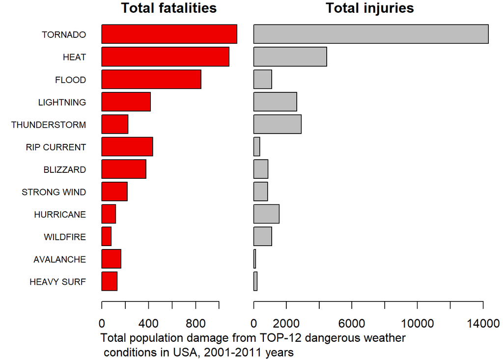

```r
#Plotting barplots for fatalities and injuries statistics
popharmSub %>%
arrange(TOTALFAT+TOTALINJ/10) %>%   #rearrange for plotting most harmful on top
with ( {
        par(mfrow=c(1,2), mar=c(4,7,1,1))
        barplot(TOTALFAT,horiz=T, names.arg = EVTYPE, cex.names = 0.75, las=1, col="red2", main="Total fatalities")
        mtext("Total population damage from TOP-12 dangerous weather",side=1,line=2, adj=0)
        mtext(" conditions in USA, 2001-2011 years",side=1,line=3, adj=0)
        par(mar=c(4,0,1,1))
        barplot(TOTALINJ,horiz=T, col="gray",main="Total injuries")
})
```

```r
with (head(popharm,1), {
print(paste("The most dangerous weather event was", EVTYPE, "which caused",
            TOTALFAT, "fatalities (", FATpercent,"% of total due to weather) and ",
            TOTALINJ, "injuries (", INJpercent, "% of total due to weather)"))
})
```

```
## [1] "The most dangerous weather event was TORNADO which caused 1152 fatalities ( 20.9 % of total due to weather) and  14332 injuries ( 44.3 % of total due to weather)"
```

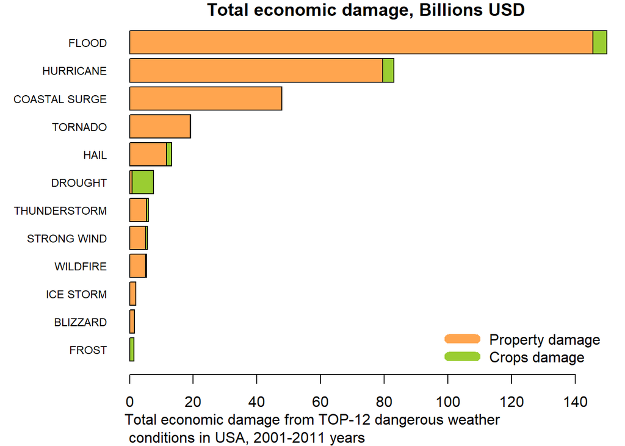

```r
#Plotting barplot for economic damage statistics
pal<-c("tan1", "yellowgreen")
ecoharmSub %>%
arrange(TOTALPROP+TOTALCROP) %>%   #rearrange for plotting most harmful on top
with ( {
        par(mfrow=c(1,1), mar=c(4,7,1,1))
        barplot(rbind(TOTALPROP/10^9, TOTALCROP/10^9), horiz=T, names.arg = EVTYPE, cex.names = 0.75, las=1,
                col=pal, beside=F, main="Total economic damage, Billions USD")
        legend("bottomright", lty = 1, lwd=10, col=pal, legend=c("Property damage", "Crops damage"), bty="n")
        mtext("Total economic damage from TOP-12 dangerous weather",side=1,line=2, adj=0)
        mtext(" conditions in USA, 2001-2011 years",side=1,line=3, adj=0)
})
```

```r
with (head(ecoharm,1), {
            (paste("The most harmful weather event was", EVTYPE, "which caused",
            TOTALPROP/10^9, "Billions USD economic damage (",
            PROPpercent,"% of total due to weather) and ",
            TOTALCROP/10^9, "Billions USD crops damage (",
            CROPpercent, "% of total due to weather)"))
})
```

```
## [1] "The most harmful weather event was FLOOD which caused 145.561841 Billions USD economic damage ( 44.8 % of total due to weather) and  4.4474759 Billions USD crops damage ( 21.9 % of total due to weather)"
```

Now we look for some uncommon peaks for better understanding if there are any rare events with significant effect:

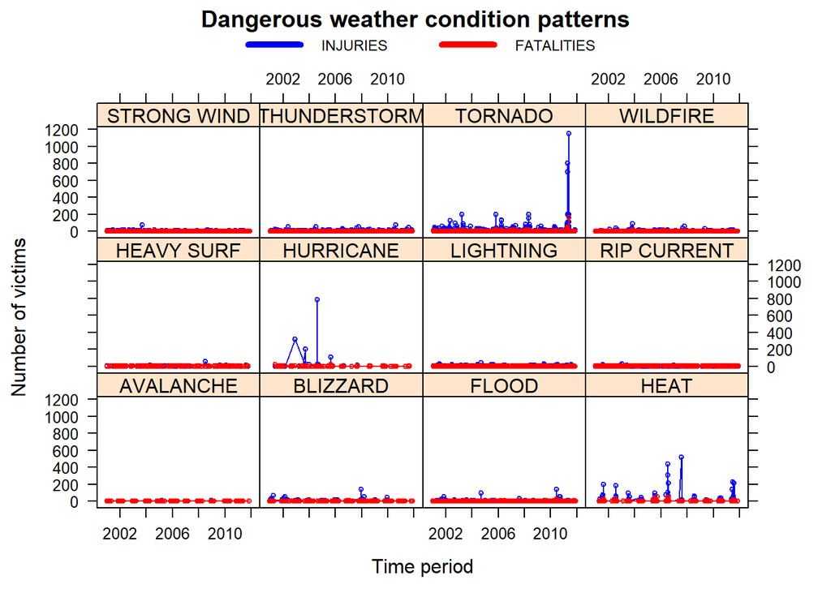

```r
library(lattice)
stormdata %>%
filter(EVTYPE %in% popharmSub$EVTYPE) %>%    #filtering just events from top-12 dangerous
with ( {
    xyplot(INJURIES+FATALITIES~BGN_DATE|EVTYPE,
           type="o", cex=0.5,
           col=c("blue","red"),
           layout=c(4,3),
           xlab="Time period",
           ylab="Number of victims",
           main="Dangerous weather condition patterns",
           key=list(space="top",
           lines=list(col=c("blue","red"), lwd=5),
           columns=2,
           text=list(c("INJURIES", "FATALITIES"),
                     cex=0.75)))
})
```

We can see, that in 2011 there was several tornadoes with significant number of victims, but this is not common annual pattern. Thanks to Wikipedia, we can find that this is [2011 Super Outbreak](https://en.wikipedia.org/wiki/2011_Super_Outbreak). Although this outlier influenced our results, we can’t simply throw away this observations, because some rare events may become more often due to the climate change. We just need to study future observations more carefully.

## Localization summary

#### TOP-1 dangerous events across the regions.

Weather conditions may differ significantly across the US, so it may be useful to look at top dangerous events across regions. As previous, we determine metric for measuring how harmful event is with respect to population health. For this study we arrange events by sum of (Total Fatalities) + (Total Injuries)/10.

```r
stormdata                            %>%
group_by(STATE,EVTYPE)               %>%    #grouping by state and event type
summarize(TOTALFAT=sum(FATALITIES),         #summarizing fatalities
          TOTALINJ=sum(INJURIES),           #summarizing injuries
          TOTALPROP=sum(PROPDMG),           #summarizing total property damage
          TOTALCROP=sum(CROPDMG))    %>%    #summarizing total crops damage
arrange(desc(STATE),
        desc(TOTALFAT+TOTALINJ/10),         #arrange events by victims
        desc(TOTALPROP+TOTALCROP)) -> statesummary  #then damage, if no victims

topdanger<-filter(statesummary, STATE=="")  #creating empty dataframe

for (i in unique(statesummary$STATE)) {     #iterating across the states
  statesummary %>%
  filter(STATE==i) %>%                      #filter specific state
  head(1) %>%                               #get TOP-1 event
  rbind(topdanger) -> topdanger
}
{
print("Summary table for TOP-1 dangerous events across the regions (property and crops damage summary included)")
print.data.frame(topdanger)
}
```

```
## [1] "Summary table for TOP-1 dangerous events across the regions (property and crops damage summary included)"
##    STATE               EVTYPE TOTALFAT TOTALINJ  TOTALPROP TOTALCROP
## 1     AK            AVALANCHE       16        8      65000         0
## 2     AL              TORNADO      280     2642 4746631700   3025000
## 3     AM MARINE/COASTAL STORM       10       30     551800     50000
## 4     AN MARINE/COASTAL STORM       12       22     278000         0
## 5     AR              TORNADO       51      623  949567700    387010
## 6     AS              TSUNAMI       32      129   81000000     20000
## 7     AZ                 HEAT       58        0          0         0
## 8     CA             WILDFIRE       34      785 3620115630 123163000
## 9     CO            AVALANCHE       38       32     416300         0
## 10    CT             BLIZZARD        3       47    4508000         0
## 11    DC         THUNDERSTORM        2       24    1633500         0
## 12    DE             BLIZZARD        6       26   12800000         0
## 13    FL          RIP CURRENT      191      149          0         0
```

[output cut: 53 more lines]

#### TOP-1 harmful events across the regions.

We can see, that dangerous weather conditions vary across the regions. Now let’s look at TOP-1 local harmful weather conditions. We use (Total property damage)+(Total crops damage) as metric for economic damage.

```r
statesummary %>%
arrange(desc(STATE),                        #rearrange events by damage
        desc(TOTALPROP+TOTALCROP))->statesummary
topharm<-filter(statesummary, STATE=="")    #creating empty dataframe
for (i in unique(statesummary$STATE)) {
  statesummary %>%
  filter(STATE==i) %>%                      #filter specific state
  head(1) %>%                               #get TOP-1 event
  rbind(topharm) -> topharm
}
{
print("Summary table for TOP-1 dangerous events across the regions (total fatalities and injuries included)")
print.data.frame(topharm)
}
```

```
## [1] "Summary table for TOP-1 dangerous events across the regions (total fatalities and injuries included)"
##    STATE               EVTYPE TOTALFAT TOTALINJ    TOTALPROP  TOTALCROP
## 1     AK                FLOOD        6        0    178920000       8000
## 2     AL              TORNADO      280     2642   4746631700    3025000
## 3     AM              TORNADO        0        0      5102000          0
## 4     AN MARINE/COASTAL STORM       12       22       278000          0
## 5     AR              TORNADO       51      623    949567700     387010
## 6     AS              TSUNAMI       32      129     81000000      20000
## 7     AZ                 HAIL        1        2   2810661000     101000
## 8     CA                FLOOD       29       57 116119411000   99860000
## 9     CO                 HAIL        0       14   1096607350   67231500
## 10    CT            HURRICANE        0        0     60004000          0
## 11    DC            HURRICANE        0        0    127400000          0
## 12    DE                FLOOD        4        4     59580000          0
## 13    FL            HURRICANE       45      810  28182204200 1022005000
```

[output cut: 53 more lines]

Harmful weather conditions also vary, and FLOOD is the most common event type. Due to different natural conditions, it’s better to specify the most dangerous and harmful weather events for each region.